# Pool Pump Calculator

First, let's look at the function to actually calculate the total cost up until time $t$:

```python
def get_cost_array(p, tmax):
    """
    Returns a list where the i'th element is the total
    cost of running the pool pump up until  time t.

    p : Dictionary
        A dictionary of parameters.  The entries are
        "PumpPrice", "Runtime", "KwHRating",
        "RunsPerMonth", and "KwHCost"

    tmax : int
        The time horizon.  For example, if tmax=24,
        the function will return a list of length
        24, where the last element is the total cost
        of the pool pump after 2 years:

    """
    cost_upto_t = [] # Initialize empty container
    intercept = p["PumpPrice"] # intercept of total cost line, see formula
    slope = p["Runtime"] * p["KwHRating"] * p["RunsPerMonth"] * p["KwHCost"]
    # The above line is just using the formula
    for t in range(0,tmax,1): # Loop through time steps
        cost_upto_t.append(intercept + slope * t) # Append the cost to the list
    return cost_upto_t
```

The code is commented but let's see how it works with an example. First we need to set the parameters dictionary:

```python
parameters = {"PumpPrice": 500,
               "Runtime": 20,
               "KwHRating": 2,
               "RunsPerMonth" : 8,
               "KwHCost": .07
             }
tmax = 60 # 5 years
```

```python
cost_vector = get_cost_array(parameters, tmax)
```

So what does this cost vector look like? What is its size?

```python
print cost_vector, '\n\n', 'The length is', len(cost_vector)
```

```
[500.0, 522.4, 544.8, 567.2, 589.6, 612.0, 634.4, 656.8, 679.2, 701.6, 724.0, 746.4000000000001, 768.8, 791.2, 813.6, 836.0, 858.4000000000001, 880.8, 903.2, 925.6, 948.0, 970.4000000000001, 992.8000000000001, 1015.2, 1037.6, 1060.0, 1082.4, 1104.8000000000002, 1127.2, 1149.6, 1172.0, 1194.4, 1216.8…

The length is 60
```

Ok so this is a list (in C# it might be an array or vector, not sure of the terminology). However, raw numbers do not tell us much so let's see what this looks like in a plot.

```python
#Ignore these lines, it just imports the plotting software
from matplotlib import pyplot as plt
%matplotlib inline
```

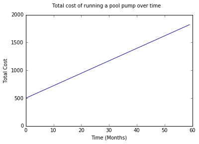

```python
# Here I will create the plot.  It is static and not interactive.
fig, ax = plt.subplots() # Create plot object
ax.plot(range(0,60,1), cost_vector) #plot the cost against time
ax.set_xlabel("Time (Months)") # Label the x axis
ax.set_ylabel("Total Cost")  # label the y axis
fig.suptitle("Total cost of running a pool pump over time") # Make the title
ax.set_ylim(0,2000); # Change axis limits;
```

Ok, so this gives us a static plot. It would make sense for you to start with this. No sliders, no interactivity. Just get used to plotting.

After that, we can talk about adding in the interactivity. My guess is that the variables in the dictionary "p" will be tied to the sliders to everytime a user moves a slider, the "p" dictionary updates, you rerun the function "get_cost_array" to get the new $y$ coordinates for the line and then update the plot with the new $y$ coordinates. However, like I said I would focus on making static plots first.